# EP08

Equipo 9

2025-05-05

```r
library(knitr)
library(ggpubr)
library(DescTools)
library(tidyverse)
library(ez)
datos = read.csv("EP08 Datos CASEN 2017.csv")
```

# Contexto

Como habíamos visto a comienzos del semestre, la Encuesta de Caracterización Socioeconómica Nacional (Casen) es realizada por el Ministerio de Desarrollo Social de forma periódica para conocer la situación de los hogares chilenos con relación a aspectos demográficos, de educación, salud, vivienda, trabajo e ingresos. Es la principal fuente de información para estimar la magnitud de la pobreza y la distribución del ingreso en el país.

Se tiene a disposición un archivo CSV con un subconjunto de los datos obtenidos en la Casen 2017. El equipo debe revisar las columnas disponibles en este archivo según la descripción en el libro de códigos de la encuesta, que también queda disponible para este ejercicio. Es importante notar que en esta encuesta hay datos de carácter colectivo sobre “el hogar” del entrevistado, pero también hay datos de carácter individual, que se refieren “al jefe o la jefa de hogar” (no al entrevistado).

# Preguntas

## Pregunta 1

Propongan una pregunta de investigación original, que involucre la comparación de una frecuencia de un evento o característica en dos grupos independientes (más abajo se dan unos ejemplos). Fijando una semilla propia, seleccionen una muestra aleatoria de hogares (100 < n < 150) y respondan la pregunta propuesta utilizando una prueba de permutaciones Monte Carlo. Indicación: creen su propio código, específicamente para este problema, no usen directamente el script del apunte.

### Respuesta

¿La distribución de las personas con un nivel académico de enseñanza media completa o superior es similar para las regiones de Tarapacá y Magallanes y la Antártica chilena?

### Desarrollo

#### Filtración de los datos

Se define una semilla para la reproducción de resultados.

```r
set.seed(548)
```

Se define el número de muestras a tomar y se separa el nivel educacional.

```r
n_muestras <- 145

regiones <- c("Región de Tarapacá", "Región de Magallanes y de la Antártica Chilena")

sin_media <- c(
  "Nunca asistió",
  "Sala cuna",
  "Jardín Infantil (Medio menor y Medio mayor)",
  "Prekinder/Kinder (Transición menor y Transición Mayor)",
  "Educación Especial (Diferencial)",
  "Primaria o Preparatoria (Sistema antiguo)",
  "Educación Básica"
)


con_media <- c(
  "Educación Media Científico-Humanista",
  "Técnica, Comercial, Industrial o Normalista (Sistema Antiguo",
  "Educación Media Técnica Profesional",
  "Técnico Nivel Superior Incompleto (Carreras 1 a 3 años)",
  "Técnico Nivel Superior Completo (Carreras 1 a 3 años)",
  "Profesional Incompleto (Carreras 4  o más años)",
  "Profesional Completo (Carreras 4 o más años)",
  "Postgrado Incompleto",
  "Postgrado Completo",
  "Humanidades (Sistema Antiguo)"
)
```

Se filtran los datos según las regiones y el nivel educacional.

```r
datosFiltrados1 <- datos %>%
  filter(region %in% regiones) %>%
  mutate(
    nivel_educacional = case_when(
      e6a %in% sin_media ~ "Sin educación media completa",
      e6a %in% con_media ~ "Con educación media completa",
    )
  ) %>%
  filter(!is.na(nivel_educacional)) %>%
  select(region, nivel_educacional) %>%
  sample_n(n_muestras)
```

Se crean tablas de contingencia de los datos.

```r
# Crear la tabla de contingencia
tabla_contingencia <- datosFiltrados1 %>%
  group_by(nivel_educacional, region) %>%
  summarise(n = n()) %>%
  pivot_wider(names_from = nivel_educacional, values_from = n)
# Proporción de personas con educación media completa
prop_table <- datosFiltrados1 %>%
  group_by(region) %>%
  summarise(
    prop_con_media = mean(nivel_educacional == "Con educación media completa")
  )

# Diferencia observada Tarapacá - Magallanes
dif_observada <- diff(prop_table$prop_con_media)

tabla_contingencia %>%
  kable(
    caption = "Distribución de nivel educacional por región",
    col.names = c("Región", "Con educación media completa", "Sin educación media completa"),
  )
```

Distribución de nivel educacional por región

| Región | Con educación media completa | Sin educación media completa |
| --- | --- | --- |
| Región de Magallanes y de la Antártica Chilena | 52 | 8 |
| Región de Tarapacá | 69 | 16 |

#### Hipótesis

- $H_0$: Las proporciones de personas con al menos educación media completa son iguales entre la región de Tarapacá y la región de Magallanes. Matemáticamente: $p_{tarapaca} - p_{magallanes} = 0$
- $H_a$: Las proporciones de personas con al menos educación media completa son distintas entre la región de Tarapacá y la región de Magallanes. Matemáticamente: $p_{tarapaca} - p_{magallanes} \neq 0$

#### Prueba de permutaciones Monte Carlo

```r
n_perm <- 4500
alfa <- 0.05

dif_permutaciones <- replicate(n_perm, {
  # Mezclar los niveles educacionales
  datosFiltrados1$region_perm <- sample(datosFiltrados1$region)

  # Calcular la diferencia de proporciones
  prop_table_permutada <- datosFiltrados1 %>%
    group_by(region_perm) %>%
    summarise(
      prop_con_media = mean(nivel_educacional == "Con educación media completa")
    )

  diff(prop_table_permutada$prop_con_media)
})
```

Se extrae el p-value y se grafica la distribución nula de diferencias.

```r
p_value <- mean(abs(dif_permutaciones) >= abs(dif_observada))
cat("p-value: ", round(p_value, 3))
```

```
## p-value:  0.494
```

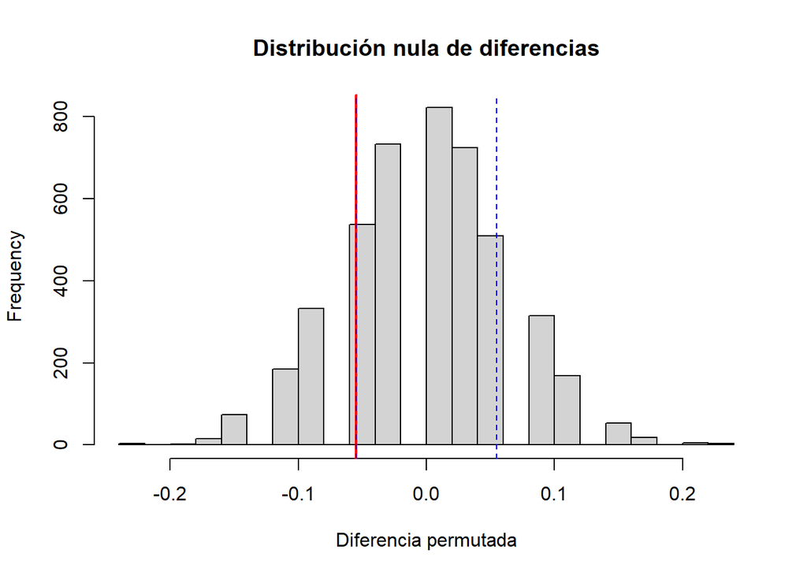

```r
hist(dif_permutaciones, breaks = 30, main = "Distribución nula de diferencias", xlab = "Diferencia permutada")
abline(v = dif_observada, col = "red", lwd = 2)
abline(v = -abs(dif_observada), col = "blue", lty = 2)
abline(v = abs(dif_observada), col = "blue", lty = 2)
```

## Pregunta 2

Propongan una pregunta de investigación original, que involucre la comparación de las medias de más de dos grupos independientes (más abajo se dan unos ejemplos). Fijando una semilla distinta a la anterior, seleccionen una muestra aleatoria de hogares (200 < n < 300) y respondan la pregunta propuesta utilizando bootstrapping. Solo por ejercicio académico, aplique un análisis post-hoc con bootstrapping aunque este no fuera necesario. Indicación: consideren que el análisis post-hoc debe hacerse con las mismas remuestras usadas para la prueba ómnibus. Escrito matematicamente:

- $H_0: \mu_{casado} = \mu_{conviviente} = \mu_{soltero}$ (Las edades promedio son iguales entre los tres estados civiles)
- $H_a: \text{Al menos una } \mu_i \neq \mu_j \text{ para } i \neq j$ (Al menos un grupo de estado civil tiene una edad promedio distinta a los demás)

### Respuesta

¿Son significativamente similares las edades de las personas según los estados civiles Casado(a), Conviviente o pareja sin acuerdo de unión civil y Soltero(a)?

### Desarrollo

```r
set.seed(765)
```

Se filtran los datos para conservar personas con los estados civiles de interés, de viviendas unicas para evitar dependencia en las observaciones y se selecciona una muestra aleatoria de entre 200 y 300 personas.

```r
datosFiltrados2 <- datos %>%
  group_by(id.vivienda) %>%
  slice_sample(n = 1) %>%
  ungroup() %>%
  filter(ecivil %in% c("Casado(a)", "Conviviente o pareja sin acuerdo de unión civil", "Soltero(a)")) %>%
  mutate(
    estado_civil = factor(ecivil,
                          levels = c("Casado(a)",
                                     "Conviviente o pareja sin acuerdo de unión civil",
                                     "Soltero(a)"),
                          labels = c("Casado(a)",
                                     "Conviviente",
                                     "Soltero(a)")
                         )
  ) %>%
  slice_sample(n = sample(200:300, 1)) %>%
  select(edad, estado_civil)
```

Análisis de las cantidades de los datos.

```r
nrow(datosFiltrados2)
```

```
## [1] 251
```

```r
summary(datosFiltrados2$estado_civil)
```

```
##   Casado(a) Conviviente  Soltero(a)
##         128          59          64
```

Grafico Q-Q de las observaciones correspondientes a cada estado civil.

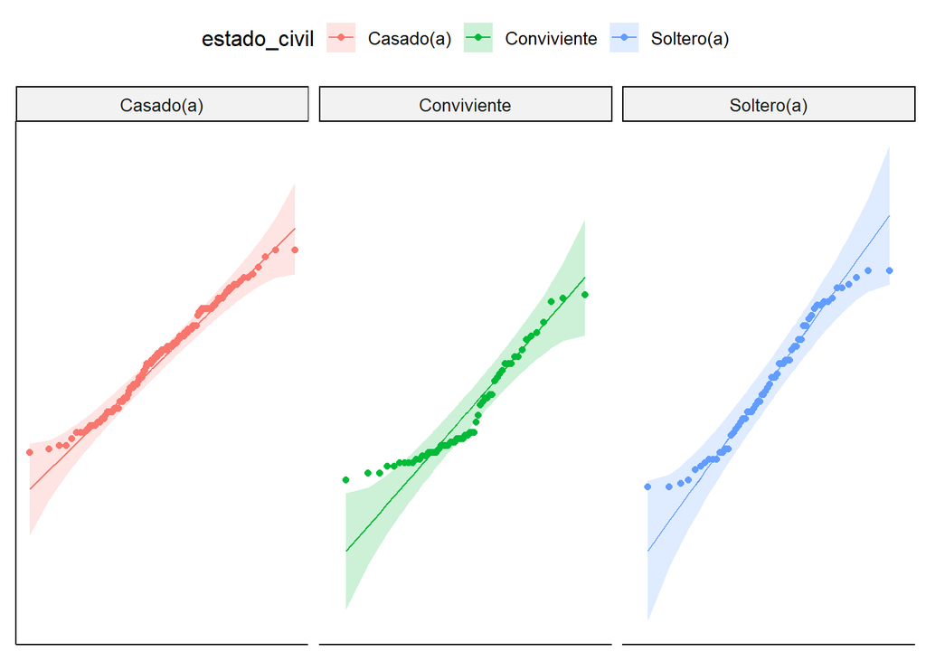

```r
grafico <- ggqqplot(datosFiltrados2,
                    x = "edad",
                    y = "estado_civil",
                    color = "estado_civil")
grafico <- grafico + facet_wrap(~estado_civil)
grafico <- grafico + rremove("x.ticks") + rremove("y.ticks")
grafico <- grafico + rremove("x.text") + rremove("y.text")
grafico <- grafico + rremove ("axis.title")
print(grafico)
```

Dado que existen observaciones extremas en las muestras que parecen no seguir una distribución normal. Se podan los extremos de los datos.

```r
gamma <- 0.25
poda <- floor(length(datosFiltrados2$edad) * gamma)

datosPodados2 <- datosFiltrados2 %>%
  arrange(edad) %>%
  slice(poda:(length(datosFiltrados2$edad) - poda))
```

Observación de las cantidades de observaciones resultantes.

```r
summary(datosPodados2$estado_civil)
```

```
##   Casado(a) Conviviente  Soltero(a)
##          77          20          31
```

Prueba de Shapiro para las muestras podadas.

```r
datosPodados2 %>%
  group_by(estado_civil) %>%
  summarise(
    n = n(),
    media = mean(edad),
    p_shapiro = shapiro.test(edad)$p.value
  )
```

```
## # A tibble: 3 × 4
##   estado_civil     n media p_shapiro
##   <fct>        <int> <dbl>     <dbl>
## 1 Casado(a)       77  53.2  0.000212
## 2 Conviviente     20  51.8  0.684
## 3 Soltero(a)      31  50.2  0.124
```

Gráfico Q-Q de los datos podados.

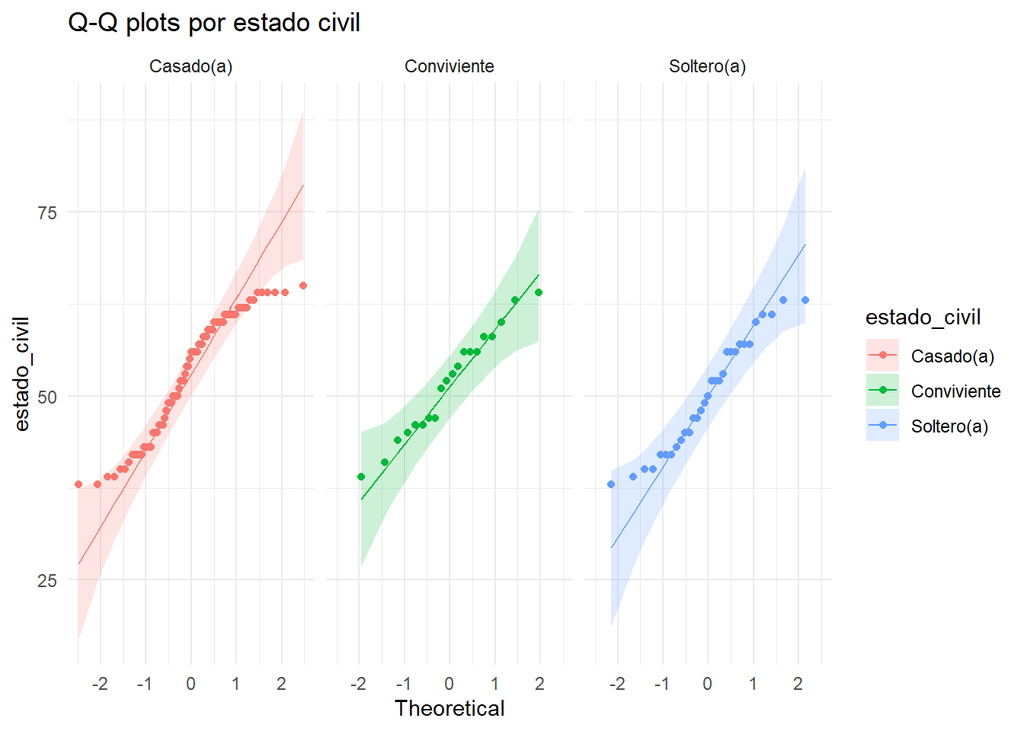

```r
ggqqplot(datosPodados2,
         x = "edad",
         y = "estado_civil",
         color = "estado_civil") +
  facet_wrap(~estado_civil) +
  theme_minimal() +
  labs(title = "Q-Q plots por estado civil")
```

Se prepararan los datos para calcular la función estadística.

```r
library(ez)
datosPodados2$id <- 1:nrow(datosPodados2)
modelo <- aov(edad ~ estado_civil, data = datosPodados2)
resumen <- summary(modelo)[[1]]
F_obs <- resumen["estado_civil", "F value"]
cat("estadistico F:", F_obs, "\n")
```

```
## estadistico F: 1.665039
```

Para cada distribución bootstrap, se calcula la función estadística F.

```r
datos_casado <- datosPodados2 %>% filter(estado_civil == "Casado(a)")
datos_conviviente <- datosPodados2 %>% filter(estado_civil == "Conviviente")
datos_soltero <- datosPodados2 %>% filter(estado_civil == "Soltero(a)")
calcular_F_grupos <- function(grupo1, grupo2, grupo3) {
  datos_combinados <- bind_rows(grupo1, grupo2, grupo3)
  datos_combinados$estado_civil <- factor(datos_combinados$estado_civil,
                                         levels = levels(datosPodados2$estado_civil))

  modelo <- aov(edad ~ estado_civil, data = datos_combinados)
  resumen <- summary(modelo)[[1]]
  return(resumen["estado_civil", "F value"])
}
F_verificacion <- calcular_F_grupos(datos_casado, datos_conviviente, datos_soltero)
cat(F_verificacion, "\n")
```

```
## 1.665039
```

Se desplazan las distribuciones bootstrap para coincidir con la hipótesis nula.

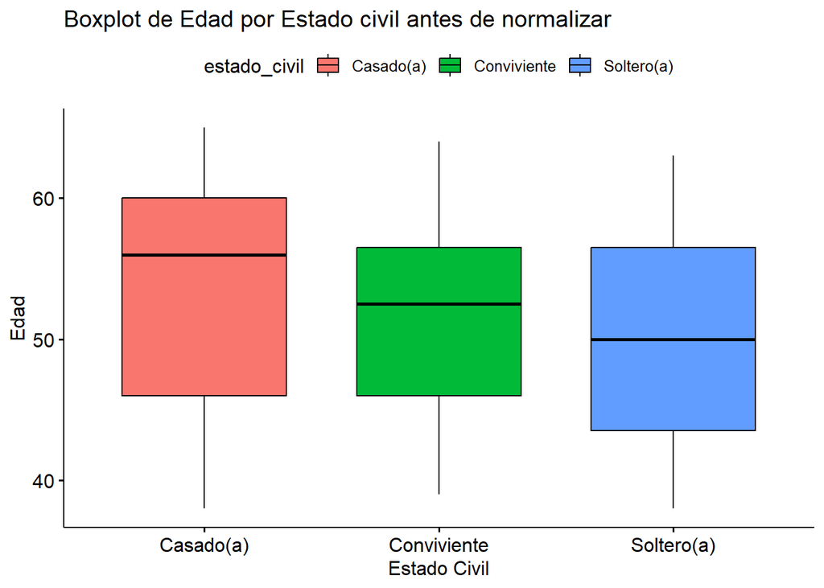

```r
g_antes <- ggboxplot(datosPodados2,
                x = "estado_civil",
                y = "edad",
                fill = "estado_civil",
                title = "Boxplot de Edad por Estado civil antes de normalizar",
                xlab = "Estado Civil",
                ylab = "Edad")
print(g_antes)
```

```r
media_general <- mean(datosPodados2$edad)
sd_general <- sd(datosPodados2$edad)

datos_H0_casado <- datos_casado %>%
  mutate(edad = media_general +
         (edad - mean(edad)) * (sd_general / sd(edad)))

datos_H0_conviviente <- datos_conviviente %>%
  mutate(edad = media_general +
         (edad - mean(edad)) * (sd_general / sd(edad)))

datos_H0_soltero <- datos_soltero %>%
  mutate(edad = media_general +
         (edad - mean(edad)) * (sd_general / sd(edad)))

bind_rows(
  datos_H0_casado %>% summarise(grupo = "Casado(a)", media = mean(edad), sd = sd(edad)),
  datos_H0_conviviente %>% summarise(grupo = "Conviviente", media = mean(edad), sd = sd(edad)),
  datos_H0_soltero %>% summarise(grupo = "Soltero(a)", media = mean(edad), sd = sd(edad))
)
```

```
## # A tibble: 3 × 3
##   grupo       media    sd
##   <chr>       <dbl> <dbl>
## 1 Casado(a)    52.3  7.90
## 2 Conviviente  52.3  7.90
## 3 Soltero(a)   52.3  7.90
```

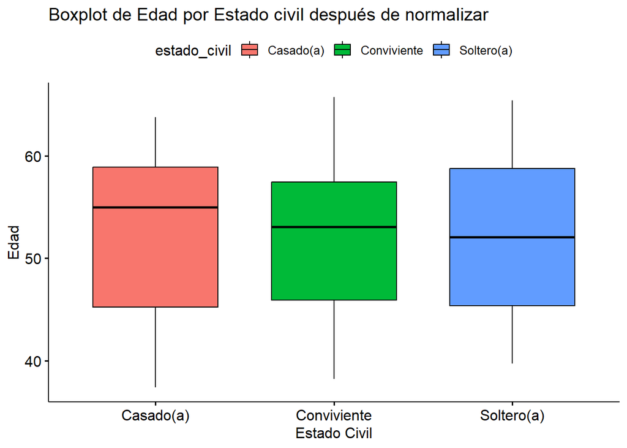

```r
datos_H0_largos <- bind_rows(
  datos_H0_casado %>% mutate(estado_civil = "Casado(a)"),
  datos_H0_conviviente %>% mutate(estado_civil = "Conviviente"),
  datos_H0_soltero %>% mutate(estado_civil = "Soltero(a)")
)

g_despues <- ggboxplot(datos_H0_largos,
                x = "estado_civil",
                y = "edad",
                fill = "estado_civil",
                title = "Boxplot de Edad por Estado civil después de normalizar",
                xlab = "Estado Civil",
                ylab = "Edad")
print(g_despues)
```

Se obtiene de la información a partir de las distribuciones bootstrap.

```r
B <- 5000
set.seed(765)

distribucion_F <- numeric(B)
#bootsreap para cada grupo
for (i in 1:B) {
  muestra_casado <- datos_H0_casado[sample(1:nrow(datos_H0_casado), replace = TRUE), ]
  muestra_conviviente <- datos_H0_conviviente[sample(1:nrow(datos_H0_conviviente), replace = TRUE), ]
  muestra_soltero <- datos_H0_soltero[sample(1:nrow(datos_H0_soltero), replace = TRUE), ]

  distribucion_F[i] <- calcular_F_grupos(muestra_casado, muestra_conviviente, muestra_soltero)
}

p_valor <- sum(distribucion_F >= F_obs) / B
cat(F_obs, "\n")
```

```
## 1.665039
```

```r
cat(p_valor, "\n")
```

```
## 0.1936
```

```r
F_crit <- quantile(distribucion_F, 0.95)
cat(F_crit, "\n")
```

```
## 2.983099
```

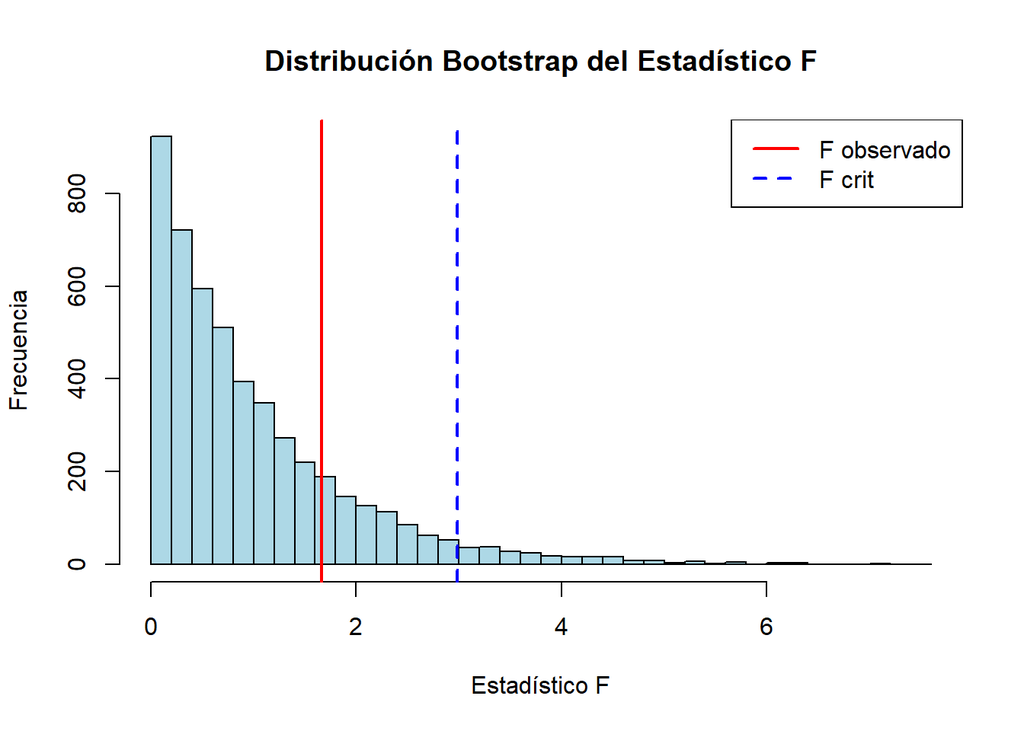

```r
hist(distribucion_F, breaks = 30,
     main = "Distribución Bootstrap del Estadístico F",
     xlab = "Estadístico F", ylab = "Frecuencia",
     col = "lightblue")
abline(v = F_obs, col = "red", lwd = 2)
abline(v = F_crit, col = "blue", lwd = 2, lty = 2)
legend("topright",
       legend = c("F observado", "F crit"),
       col = c("red", "blue"),
       lty = c(1, 2),
       lwd = 2)
```

## Post-hoc

Aunque el anova no indica diferencias significativas, se realiza un post-hoc en base a las instrucciones del ejercicio academico

```r
casado_conviviente <- mean(datos_casado$edad) - mean(datos_conviviente$edad)
casado_soltero <- mean(datos_casado$edad) - mean(datos_soltero$edad)
conviviente_soltero <- mean(datos_conviviente$edad) - mean(datos_soltero$edad)
```

Bootstrap para las diferencia de los grupos

```r
boot_casado_conviviente <- numeric(B)
boot_casado_soltero <- numeric(B)
boot_conviviente_soltero <- numeric(B)
for (i in 1:B) {
  muestra_casado <- datos_H0_casado[sample(1:nrow(datos_H0_casado), replace = TRUE), ]
  muestra_conviviente <- datos_H0_conviviente[sample(1:nrow(datos_H0_conviviente), replace = TRUE), ]
  muestra_soltero <- datos_H0_soltero[sample(1:nrow(datos_H0_soltero), replace = TRUE), ]
  boot_casado_conviviente[i] <- mean(muestra_casado$edad) - mean(muestra_conviviente$edad)
  boot_casado_soltero[i] <- mean(muestra_casado$edad) - mean(muestra_soltero$edad)
  boot_conviviente_soltero[i] <- mean(muestra_conviviente$edad) - mean(muestra_soltero$edad)
}
```

Valores p

```r
Pcasado_conviviente <- sum(abs(boot_casado_conviviente) >= abs(casado_conviviente)) / B
Pcasado_soltero <- sum(abs(boot_casado_soltero) >= abs(casado_soltero)) / B
Pconviviente_soltero <- sum(abs(boot_conviviente_soltero) >= abs(conviviente_soltero)) / B

cat("Casado - Conviviente:", Pcasado_conviviente, "\n")
```

```
## Casado - Conviviente: 0.4564
```

```r
cat("Casado - Soltero:", Pcasado_soltero, "\n")
```

```
## Casado - Soltero: 0.0708
```

```r
cat("Conviviente - Soltero:", Pconviviente_soltero, "\n")
```

```
## Conviviente - Soltero: 0.4898
```

Todos los valores p estan sobre el nivel de significacion, lo que confirma que no existe diferencia significativa entre los pares

Intervalos de confianza para ver las diferencias

```r
bootcasado_conviviente <- numeric(B)
bootcasado_soltero <- numeric(B)
bootconviviente_soltero <- numeric(B)

for (i in 1:B) {
  #datos originales
  muestra_casado <- datos_casado[sample(1:nrow(datos_casado), replace = TRUE), ]
  muestra_conviviente <- datos_conviviente[sample(1:nrow(datos_conviviente), replace = TRUE), ]
  muestra_soltero <- datos_soltero[sample(1:nrow(datos_soltero), replace = TRUE), ]
  #diferencias por cada observacion
  bootcasado_conviviente[i] <- mean(muestra_casado$edad) - mean(muestra_conviviente$edad)
  bootcasado_soltero[i] <- mean(muestra_casado$edad) - mean(muestra_soltero$edad)
  bootconviviente_soltero[i] <- mean(muestra_conviviente$edad) - mean(muestra_soltero$edad)
}


ic_casado_conviviente <- quantile(bootcasado_conviviente, c(0.025, 0.975))
ic_casado_soltero <- quantile(bootcasado_soltero, c(0.025, 0.975))
ic_conviviente_soltero <- quantile(bootconviviente_soltero, c(0.025, 0.975))
cat("Casado Conviviente:", ic_casado_conviviente[1], ic_casado_conviviente[2], "\n")
```

```
## Casado Conviviente: -2.133133 5.053312
```

```r
cat("Casado Soltero:", ic_casado_soltero[1], ic_casado_soltero[2], "\n")
```

```
## Casado Soltero: -0.2538961 6.25863
```

```r
cat("Conviviente Soltero:", ic_conviviente_soltero[1], ic_conviviente_soltero[2], "\n")
```

```
## Conviviente Soltero: -2.500323 5.653548
```

Los 3 intervalos incluyen el 0, confirmando nuevamente que las diferencias observadas no son estadisticamente significativas